# ASS2

## Introduction

In this analysis, I separate the Degree of injury into Non-Critical and Critical. Critical injuries are ones that result in Permanent total or Permanent partial Disabilities, or Fatalities; Non-critical injuries are everything else. I then perform classification on this data to determine if there are any relationships between the regressors and critical or non-critical injuries.

I then perform Clustering on the data without the response variable to ascertain if there are common patterns in the data that cannot be picked up by regression classification algorithms.

# Set up

```r
library(dplyr)
library(ggplot2)
library(sqldf)
library(ROCR)
library(purrr)
library(lime)
library(xgboost)
library(ggthemes)
library(ggpubr)
library(fpc)

Data = read.csv("Cleaned Data.csv", header = T)
ass2_theme <- theme_few() +
                  theme(axis.text.y=element_text(size=rel(0.8)))+
                  theme(plot.margin=margin(10,30,10,30))+
                  grids(linetype ="dashed", color = "black", size = 0.5)
```

### Further data preparations

Selecting columns to be used in the classification.

```r
# Selecting data to use in analysis.

analysis_data = subset(Data,select = c("MINE_ID", "CONTROLLER_ID", "OPERATOR_ID", "SUBUNIT", "UG_LOCATION", "CAL_YR","UG_MINING_METHOD", "COAL_METAL_IND","CONTRACTOR_ID", "DEGREE_INJURY", "ACCIDENT_TYPE" ,"ACCIDENT_TIME", "ACCIDENT_TIME_isBAD", "TOT_EXPER","CLASSIFICATION", "OCCUPATION" , "SHIFT_BEGIN_TIME", "SHIFT_BEGIN_TIME_isBAD","ACTIVITY", "MINING_EQUIP"))
```

The predictor variables were chosen following the relationships discovered in the exploratory data analysis stage.

### Creating target variable

```r
analysis_data = mutate(analysis_data,
                       LEVEL = ifelse((DEGREE_INJURY =="PERM TOT OR PERM PRTL DISABLTY" | DEGREE_INJURY == "FATALITY"), 1, 0))

for(vr in names(analysis_data)){
  analysis_data[,vr]= na_if(analysis_data[,vr],"NO VALUE FOUND")


}
analysis_data$MINE_ID = as.factor(analysis_data$MINE_ID)
#CRITICA == 1 NON_CRITICAL == 0
pos_label = 1
```

### checking balance of response variable

```r
resp_tab = table(analysis_data$LEVEL)
round(prop.table(x = resp_tab), 3)
```

```
    0     1
0.987 0.013
```

The data is skewed in favour of Non-critical injuries. Where non-critical injuries make up around 98.7 percent of the data set.I will not alter the data set but choose comparison stats that account for the skew in data.

### Splitting data

Since I will be using the model to predict future incidents, I will split the data by years.With a 0.9, 0.1 split.

```r
# find cumulative function over years.
prop = function(x, column1, column2 ){
  year_level_table = prop.table(table(x[,column1],x[, column2]))
  year_level_table = cbind(year_level_table, cumsum(year_level_table[,1] + year_level_table[,2]))

  colnames(year_level_table)[3] <- "CUMULATIVE"

}

prop(analysis_data, "CAL_YR", "LEVEL")
# split the data at 2013 since this will give an approximat 0.9, 0.1 split

split_data  = function(x, split_column, split_date){
  rvalue = x[,split_column]
  list(x[rvalue <= split_date, ], x[rvalue > split_date, ])
}
training_test_data = split_data(analysis_data,"CAL_YR", 2012)
training_calibration_data = training_test_data[[1]]
test_data = training_test_data[[2]]

rm(training_test_data)
```

Splitting training into calibration and training sets.

```r
prop(training_calibration_data, "CAL_YR", "LEVEL")
train_calibratrion_data = split_data(training_calibration_data,"CAL_YR", 2010)
training_data = train_calibratrion_data[[1]]
calibration_data = train_calibratrion_data[[2]]
```

Splitting the variables into Categorical and numerical variables

```r
cat_vars = setdiff(names(training_data[,lapply(training_data, class) %in% c('factor','character')]),c("LEVEL","DEGREE_INJURY"))
num_vars = setdiff(names(training_data[,lapply(training_data, class) %in% c('numeric','integer')]),c("LEVEL","DEGREE_INJURY"))
```

# Classification

## Implement Base models i.e single variable model

```r
## code adopted from WEEK 9 lecture Prepared by Dr Du Huynh for Demonstrative purposes.
mkPredC <- function(outCol,varCol,appCol, pos=pos_label) {
  pPos <- sum(outCol==pos)/length(outCol)
  naTab <- table(as.factor(outCol[is.na(varCol)]))
  pPosWna <- (naTab/sum(naTab))[pos]
  vTab <- table(as.factor(outCol),varCol)
  pPosWv <- (vTab[pos,]+1.0e-3*pPos)/(colSums(vTab)+1.0e-3)
  pred <- pPosWv[appCol]
  pred[is.na(appCol)] <- pPosWna
  pred[is.na(pred)] <- pPos
  pred
}
```

```r
outcome = "LEVEL"

## Making predictions for all three data sets.
for(v in cat_vars) {
  cname <- paste('pred',v,sep='')
  training_data[,cname] <- mkPredC(training_data[,outcome], training_data[,v], training_data[,v])
  calibration_data[,cname] <- mkPredC(training_data[,outcome], training_data[,v], calibration_data[,v])
  test_data[,cname] <- mkPredC(training_data[,outcome], training_data[,v], test_data[,v])
}
```

## Evaluating Single variable Models

### Categorical variable

```r
calcAUC <- function(predcol, outcol, pos=pos_label) {
  perf <- performance(prediction(predcol, outcol==pos),'auc')
  as.numeric(perf@y.values)
}

for(v in cat_vars) {
  cname <- paste('pred',v,sep='')
  aucTrain <- calcAUC(training_data[,cname],training_data[,outcome])
  if(aucTrain>=0.4) {
    aucCal <- calcAUC(calibration_data[,cname],calibration_data[,outcome])
    print(sprintf(
      "%s, trainAUC: %4.3f calibrationAUC: %4.3f",
      cname, aucTrain, aucCal))
  }
}
```

```
[1] "predSUBUNIT, trainAUC: 0.464 calibrationAUC: 0.498"
[1] "predUG_LOCATION, trainAUC: 0.468 calibrationAUC: 0.491"
[1] "predUG_MINING_METHOD, trainAUC: 0.472 calibrationAUC: 0.483"
[1] "predCOAL_METAL_IND, trainAUC: 0.486 calibrationAUC: 0.506"
[1] "predCONTRACTOR_ID, trainAUC: 0.404 calibrationAUC: 0.500"
```

##### 5 fold cross validation

```r
for (var in cat_vars) {
  aucs = rep(0,5)
  for (i in seq(0,4)) {
    cal = analysis_data$CAL_YR >=  i*3+2000 & analysis_data$CAL_YR <= i *3 +2003

    predRep <- mkPredC(analysis_data[!cal, outcome],
                       analysis_data[!cal, var],
                       analysis_data[cal, var])
    aucs[i+1] <- calcAUC(predRep, analysis_data[cal, outcome])
  }
  print(sprintf("%s: mean: %4.3f; sd: %4.3f", var, mean(aucs), sd(aucs)))
}
```

```
[1] "MINE_ID: mean: 0.478; sd: 0.013"
[1] "CONTROLLER_ID: mean: 0.475; sd: 0.012"
[1] "OPERATOR_ID: mean: 0.479; sd: 0.011"
[1] "SUBUNIT: mean: 0.470; sd: 0.015"
[1] "UG_LOCATION: mean: 0.490; sd: 0.019"
[1] "UG_MINING_METHOD: mean: 0.482; sd: 0.003"
[1] "COAL_METAL_IND: mean: 0.488; sd: 0.014"
[1] "CONTRACTOR_ID: mean: 0.486; sd: 0.011"
[1] "ACCIDENT_TYPE: mean: 0.185; sd: 0.021"
[1] "CLASSIFICATION: mean: 0.272; sd: 0.014"
[1] "OCCUPATION: mean: 0.400; sd: 0.021"
[1] "ACTIVITY: mean: 0.304; sd: 0.013"
[1] "MINING_EQUIP: mean: 0.331; sd: 0.010"
```

With the 5-fold cross validation, the UG_location variable is the best single variable model for categorical variables; AUC of 0.49. The initial auc prediction were underestimates for the top 5 variables.

```r
# Eliminating variables
cat_vars = setdiff(cat_vars, c("OCCUPATION", "ACTIVITY", "CLASSIFICATION", "ACCIDENT_TYPE", "MINING_EQUIP"))
```

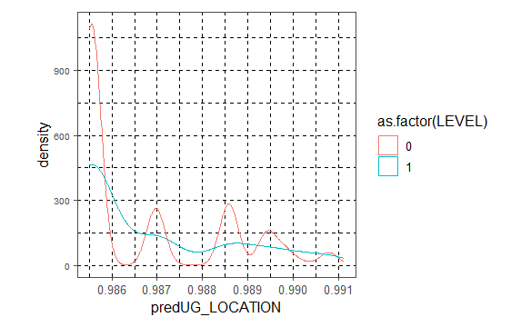

```r
ggplot(data=calibration_data) +
  geom_density(aes(x=predUG_LOCATION,color=as.factor(LEVEL))) +
  ass2_theme
```

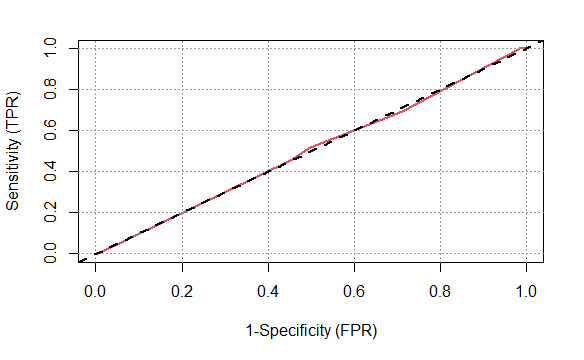

```r
library(ROCit)
plot_roc <- function(predcol, outcol, colour_id=2, overlaid=F) {
ROCit_obj <- rocit(score=predcol, class=outcol==pos_label)
par(new=overlaid)
plot(ROCit_obj, col = c(colour_id, 1),
legend = FALSE, YIndex = FALSE, values = FALSE)
}
plot_roc(calibration_data$predSUBUNIT, calibration_data[, outcome])
```

Even though the UG_location single variable model is the best categorical model, its is barely able to differentiate between the two LEVELS of injuries. The double density plot shows that there is considerable overlap between the density of the two injury levels, with no descernable threshold value to separate the two classes. Thus, changing the threshold value will not produce a better results as the model is unable to differentiate between the two classes.

### numerical variables

```r
# Prediction function for numerical variables
mkPredN <- function(outCol,varCol,appCol) {
  cuts <- unique(as.numeric(quantile(varCol, probs=seq(0, 1, 0.1), na.rm=T)))
  varC <- cut(varCol, cuts)
  appC <- cut(appCol, cuts)
  mkPredC(outCol, varC, appC)
}
```

```r
for(v in num_vars) {
  cname <- paste('pred',v,sep='')
  training_data[,cname] <- mkPredN(training_data[,outcome], training_data[,v], training_data[,v])
  calibration_data[,cname] <- mkPredN(training_data[,outcome], training_data[,v], calibration_data[,v])
  test_data[,cname] <- mkPredN(training_data[,outcome], training_data[,v], test_data[,v])

  aucTrain <- calcAUC(training_data[,cname],training_data[,outcome])
  if(aucTrain>=0.4) {
    aucCal <- calcAUC(calibration_data[,cname],calibration_data[,outcome])
    print(sprintf(
      "%s, trainAUC: %4.3f calibrationAUC: %4.3f",
      cname, aucTrain, aucCal))
  }
}
```

```
[1] "predCAL_YR, trainAUC: 0.466 calibrationAUC: 0.500"
[1] "predACCIDENT_TIME, trainAUC: 0.459 calibrationAUC: 0.509"
[1] "predACCIDENT_TIME_isBAD, trainAUC: 0.477 calibrationAUC: 0.478"
[1] "predTOT_EXPER, trainAUC: 0.418 calibrationAUC: 0.401"
[1] "predSHIFT_BEGIN_TIME, trainAUC: 0.467 calibrationAUC: 0.480"
[1] "predSHIFT_BEGIN_TIME_isBAD, trainAUC: 0.491 calibrationAUC: 0.494"
```

##### 5-fold Cross validation

```r
for (var in num_vars) {
  aucs = rep(0,5)
  for (i in seq(0,4)) {
    cal = analysis_data$CAL_YR >=  i*3+2000 & analysis_data$CAL_YR <= i *3 +2003

    predRep <- mkPredN(analysis_data[!cal, outcome],
                       analysis_data[!cal, var],
                       analysis_data[cal, var])
    aucs[i+1] <- calcAUC(predRep, analysis_data[cal, outcome])
  }
  print(sprintf("%s: mean: %4.3f; sd: %4.3f", var, mean(aucs), sd(aucs)))
}
```

```
[1] "CAL_YR: mean: 0.500; sd: 0.000"
[1] "ACCIDENT_TIME: mean: 0.476; sd: 0.006"
[1] "ACCIDENT_TIME_isBAD: mean: 0.476; sd: 0.004"
[1] "TOT_EXPER: mean: 0.424; sd: 0.016"
[1] "SHIFT_BEGIN_TIME: mean: 0.479; sd: 0.009"
[1] "SHIFT_BEGIN_TIME_isBAD: mean: 0.493; sd: 0.005"
```

With cross validation, calender year becomes the most important variable for the single variable models, being the only model with an AUC of 0.5. Another interesting observation is, the calender Years AUC has a standard deviation of 0.

# Multi Variable Models

### Model Evaluation

```r
plot_roc2 <- function(predcol1, outcol1, predcol2, outcol2){
  roc_1 <- rocit(score=predcol1, class=outcol1==pos_label)
  roc_2 <- rocit(score=predcol2, class=outcol2==pos_label)
  plot(roc_1, col = c("blue","green"), lwd = 3,
       legend = FALSE, YIndex = FALSE, values = TRUE, cex=3)
  lines(roc_2$TPR ~ roc_2$FPR, lwd = 3, col = c("red","green"), cex=3)
  legend("bottomright", col = c("blue","red", "green"),
         c("Train", "Test", "Null Model"), lwd = 2, cex=2)
}

logLikelihood <- function(ytrue, ypred) {
  sum(ifelse(ytrue==pos_label, log(ypred), log(1-ypred)), na.rm=T)
}

logNull <- logLikelihood(
  calibration_data[,outcome], sum(calibration_data[,outcome]==pos_label )/nrow(calibration_data)
)

performanceMeasures <- function(ytrue, ypred, model.name = "model") {
  # compute the normalised deviance
  dev.norm <- -2 * logLikelihood(ytrue, ypred)/length(ypred)
  # compute the confusion matrix
   cmat <- table(actual = ytrue, predicted = ypred)
  accuracy <- sum(diag(cmat)) / sum(cmat)
  precision <- cmat[2, 2] / sum(cmat[, 2])
  recall <- cmat[2, 2] / sum(cmat[2, ])
  f1 <- 2 * precision * recall / (precision + recall)
  data.frame(model = model.name, precision = precision,
             recall = recall, f1 = f1, dev.norm = dev.norm)
}
#
# trainperf_df <- performanceMeasures(
#   ytrain, pred_train >= threshold, model.name="training")
# testperf_df <- performanceMeasures(
#   ytest, pred_test >= threshold, model.name="test")


pretty_perf_table <- function(pred_train, pred_test ,training,test) {
  library(pander)
  # setting up Pander Options
  panderOptions("plain.ascii", TRUE)
  panderOptions("keep.trailing.zeros", TRUE)
  panderOptions("table.style", "simple")
  perf_justify <- "lrrrr"
  # comparing performance on training vs. test

  truth_train <- training[, "LEVEL"]

  truth_test <- test[, "LEVEL"]
  trainperf_tree <- performanceMeasures(
    pred_train, truth_train, "training")
  testperf_tree <- performanceMeasures(
    pred_test, truth_test, "test")
  perftable <- rbind(trainperf_tree, testperf_tree)

  pandoc.table(perftable, justify = perf_justify)
}



model_evaluation = function( train, test, pos = pos_label, model, threshold = 0.5, type = NULL, pred_train, pred_test){
  # ROC plot


  plot_roc2(pred_train, train[, outcome], pred_test, test[, outcome] )



  ### confusion matrix
  conf_mat = table(test$LEVEL, as.numeric(pred_test > threshold))
  ### Performance Measure
  pretty_perf_table(pred_train>threshold, pred_test>threshold, train, test)
  library(knitr)
  print(kable(conf_mat))
  ### Density Plot

  temp_data = test
  temp_data$prediction = pred_test

  p1 = ggplot(data= temp_data) +
    geom_density(aes(x = prediction,color=as.factor(LEVEL)))+
    ass2_theme

  print(p1)

  ## precision and Recall and f1 score

  perf_prec = performance(prediction(pred_test, test[,outcome]), measure = "prec")
  perf_rec = performance(prediction(pred_test, test[,outcome]), measure = "rec")

  thresh = perf_prec@x.values[[1]]
  precision = perf_prec@y.values[[1]]
  recal = perf_rec@y.values[[1]]
  f1_score = 2*precision*recal/(precision + recal)
  p2 = ggplot() + geom_line(aes(x = thresh, y = f1_score), colour = "red")+
    ass2_theme
  print(p2)
  ### AUC
  aucTrain <- calcAUC(pred_train, train[,outcome])

  aucCal <- calcAUC(pred_test, test[,outcome])
  print(sprintf(
  "trainAUC: %4.3f; calibrationAUC: %4.3f",
  aucTrain, aucCal))


}
```

### Selecting variables

```r
#
pred_var = names(calibration_data)[grepl("pred", names(calibration_data))]
var_cor = cor(training_data[pred_var])
pred_var = setdiff( pred_var, c("predOPERATOR_ID", "predCONTROLLER_ID") )
```

I eliminate one of a pair of variables with high correlation, namely, predOPERATOR_ID and predCONTROLLER_ID.

## Decision Tree

```r
library(rpart)

#predicted values from Single viable model are used because the categorical variables have a larger number of levels.

formula = paste("LEVEL" , paste(pred_var, collapse =  "+"),sep = "~" )
D_tree = rpart( formula , data = training_data)
```

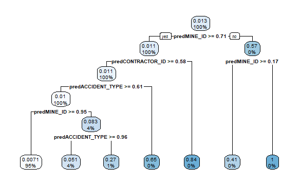

```r
## Use Predictions to creat model if you want to Plot
library(rpart.plot)
rpart.plot(D_tree)
```

The decision tree suggests that Mines, Contractor operating the mines, and accident type are the determining factors for the level of Injury for each incident. E.G. the incidents might be highly influenced by the adherence to safety standards by the contractor and underlying risk involved in working at different mines. I test how good the model is.

```
model        precision    recall        f1   dev.norm
---------- ----------- --------- --------- ----------
training        0.1550   0.84777   0.26207        Inf
test            0.1863   0.02532   0.04459        Inf
```

|  | 0 | 1 |
| --- | --- | --- |
| 0 | 18906 | 1886 |
| 1 | 214 | 49 |

```
[1] "trainAUC: 0.732; calibrationAUC: 0.553"
```

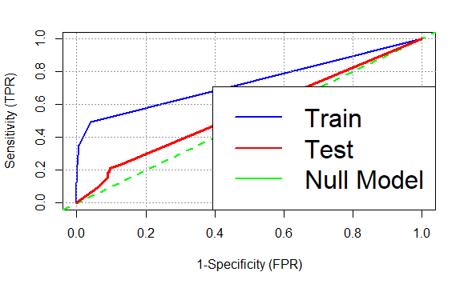

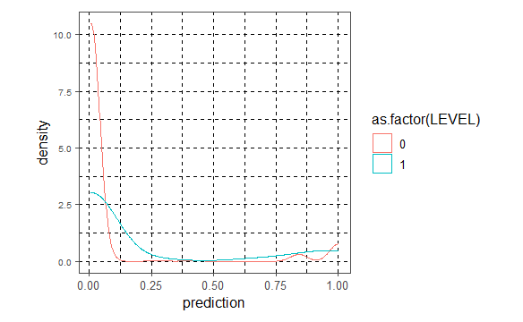

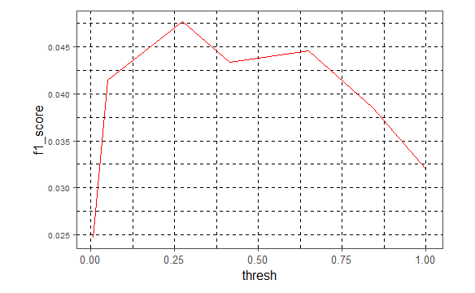

```r
model_evaluation(training_data,calibration_data, model =D_tree, pred_test = predict(D_tree, newdata = calibration_data),  pred_train = predict(D_tree, newdata = training_data))
```

With an AUC of 0.553, the decision tree model is better than the best single variable “Calender year” and the NUll model, both of which have an AUC of 0.5. The model is still inaccurate at predicting our LEVEL of choice, CRIRICAL injuries ie 1. Adjusting the threshold value might give better results but from the density plot, it is clear that the model is unable to differentiate the two LEVES of injury because there is significant overlap of the probability values given to each level. The two levels’ prediction values are mostly below 0.375. Thus even though the model is better than the null model, it is not useful for explaining or predicting CRITICAL injuries

Trying new threshold value

```r
thresholds = unique(predict(D_tree, newdata = calibration_data)) ### using predicted values as threshold
table(predict(D_tree, newdata = calibration_data) > thresholds[1], calibration_data[, outcome])
```

```
            0     1
  FALSE 18126   201
  TRUE   2666    62
```

```r
table(predict(D_tree, newdata = calibration_data) > thresholds[3], calibration_data[, outcome])
```

```
            0     1
  FALSE 18762   207
  TRUE   2030    56
```

There is an increase in the number of correctly identified CRITICAL INJURIES, but I also get an increase in the number of false positive. IE adjusting the threshold value increases the model sensitivity but decreases specificity making the model unusable

## Logistic Regression

```r
## using train to perform logistic regression for future explanation
model <- caret::train(x = training_data[pred_var], y = as.factor(training_data[,outcome]),
               method = "glm", family = binomial(link="logit"))
```

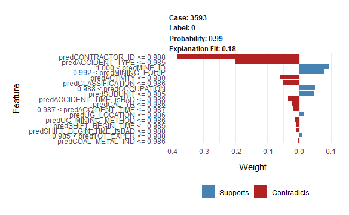

```r
###


explainer = lime(training_data[,pred_var], model = model ,
                  bin_continuous = TRUE)
case1 <- c("3593")
case2 <- c("3485")
explanation1 = explain(calibration_data[case1,pred_var], explainer, n_labels = 1, n_features = length(pred_var))

explanation2 = explain(calibration_data[case2,pred_var], explainer, n_labels = 1, n_features = length(pred_var))
plot_features(explanation1)
```

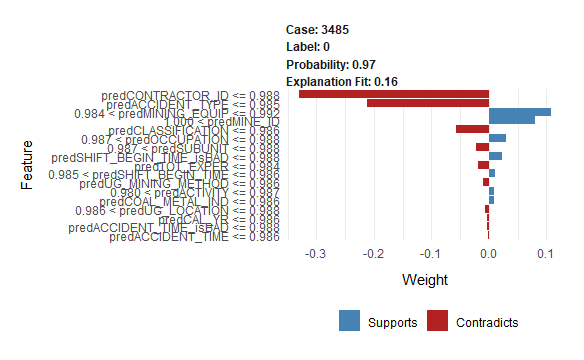

```r
plot_features(explanation2)
```

The logistic regression model, much like decision trees, places an emphasis on contractor_ID, mine_ID and Accident type to differentiate the two levels, but there are additional variables that affect the labeling e.g. Mining equipment .That said, 1/2 of the labels predicted are incorrect but the small sample size might be a reason for this observation.

Further exploration

```r
formula = paste("LEVEL" , paste(pred_var, collapse =  "+"),sep = "~" )
log_model  = glm(formula = formula, data = training_data, family = "binomial")
summary(log_model)
```

```
Call:
glm(formula = formula, family = "binomial", data = training_data)

Deviance Residuals:
    Min       1Q   Median       3Q      Max
-3.5785  -0.1335  -0.0993  -0.0743   3.7473

Coefficients:
                           Estimate Std. Error z value Pr(>|z|)
(Intercept)                208.5382    52.9750   3.937 8.27e-05 ***
predMINE_ID                -13.7737     0.3090 -44.574  < 2e-16 ***
predSUBUNIT                 92.0258    19.2774   4.774 1.81e-06 ***
predUG_LOCATION             14.1923    22.0189   0.645   0.5192
predUG_MINING_METHOD       -28.2878    16.1035  -1.757   0.0790 .
predCOAL_METAL_IND         106.1224    44.6790   2.375   0.0175 *
predCONTRACTOR_ID          -10.7650     0.5771 -18.653  < 2e-16 ***
predACCIDENT_TYPE          -10.9007     0.4904 -22.228  < 2e-16 ***
predCLASSIFICATION         -26.6017     1.9260 -13.812  < 2e-16 ***
predOCCUPATION             -22.4617     2.4578  -9.139  < 2e-16 ***
predACTIVITY               -19.4029     1.7904 -10.837  < 2e-16 ***
predMINING_EQUIP           -21.4774     1.6869 -12.732  < 2e-16 ***
predCAL_YR                 -90.0528    16.3051  -5.523 3.33e-08 ***
predACCIDENT_TIME           -7.3819    14.9659  -0.493   0.6218
predACCIDENT_TIME_isBAD     -9.4830    19.9114  -0.476   0.6339
predTOT_EXPER              -89.9624     9.3887  -9.582  < 2e-16 ***
predSHIFT_BEGIN_TIME       -30.2222    15.6873  -1.927   0.0540 .
predSHIFT_BEGIN_TIME_isBAD -48.2060    37.2364  -1.295   0.1955
---
Signif. codes:  0 ‘***’ 0.001 ‘**’ 0.01 ‘*’ 0.05 ‘.’ 0.1 ‘ ’ 1

(Dispersion parameter for binomial family taken to be 1)

    Null deviance: 22156  on 157060  degrees of freedom
Residual deviance: 14673  on 157043  degrees of freedom
AIC: 14709

Number of Fisher Scoring iterations: 8
```

```
model        precision    recall        f1   dev.norm
---------- ----------- --------- --------- ----------
training        0.2342   0.73494   0.35517        Inf
test            0.1939   0.02585   0.04562        Inf
```

|  | 0 | 1 |
| --- | --- | --- |
| 0 | 18870 | 1922 |
| 1 | 212 | 51 |

```
[1] "trainAUC: 0.909; calibrationAUC: 0.766"
```

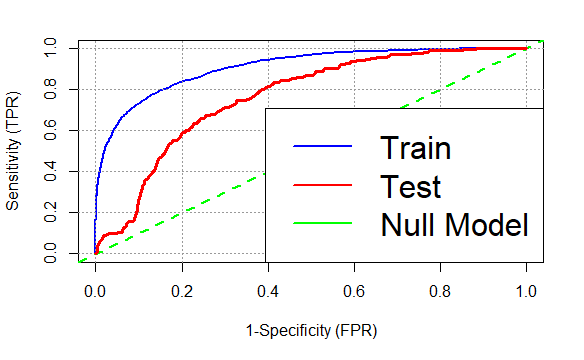

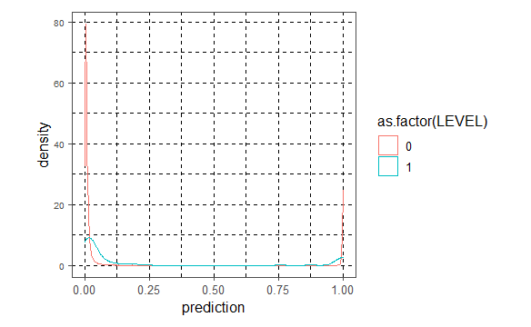

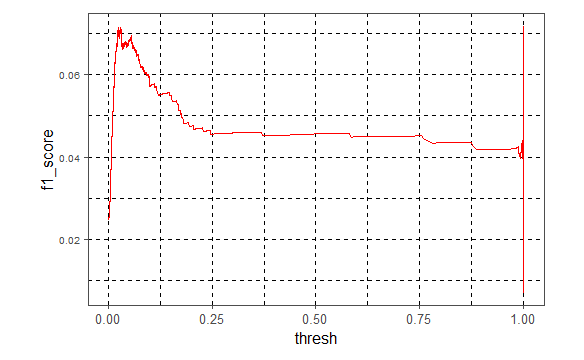

```r
model_evaluation(training_data,calibration_data, model =log_model, pred_test = predict(log_model, newdata = calibration_data, type = "response"),  pred_train = predict(log_model, newdata = training_data, type = "response"), threshold = 0.5)
```

Eliminating insignificant variables nad lowerig the threshold score

```r
## using train to perform logistic regression for future explanation
model2 <- caret::train(x = training_data[setdiff(pred_var,c( "predUG_LOCATION", "predUG_MINING_METHOD" ,"predCOAL_METAL_IND", "predSHIFT_BEGIN_TIME", "predSHIFT_BEGIN_TIME_isBAD", "predACCIDENT_TIME","predACCIDENT_TIME_isBAD" ))], y = as.factor(training_data[,outcome]),
               method = "glm", family = binomial(link="logit"))
```

```r
formula2 = paste("LEVEL" , paste(setdiff(pred_var,c( "predUG_LOCATION", "predUG_MINING_METHOD" ,"predCOAL_METAL_IND", "predSHIFT_BEGIN_TIME", "predSHIFT_BEGIN_TIME_isBAD", "predACCIDENT_TIME","predACCIDENT_TIME_isBAD" )), collapse =  "+"),sep = "~" )

log_model_sel  = glm(formula = formula2, data = training_data, family = "binomial")
summary(log_model_sel)
```

```
Call:
glm(formula = formula2, family = "binomial", data = training_data)

Deviance Residuals:
    Min       1Q   Median       3Q      Max
-3.5639  -0.1334  -0.0998  -0.0754   3.6591

Coefficients:
                   Estimate Std. Error z value Pr(>|z|)
(Intercept)        198.0391    23.7798   8.328  < 2e-16 ***
predMINE_ID        -13.7418     0.3079 -44.636  < 2e-16 ***
predSUBUNIT        102.8654    14.8898   6.908 4.90e-12 ***
predCONTRACTOR_ID  -10.8881     0.5790 -18.804  < 2e-16 ***
predACCIDENT_TYPE  -10.8566     0.4909 -22.115  < 2e-16 ***
predCLASSIFICATION -27.0463     1.9147 -14.126  < 2e-16 ***
predOCCUPATION     -22.8596     2.4668  -9.267  < 2e-16 ***
predACTIVITY       -19.4564     1.7920 -10.857  < 2e-16 ***
predMINING_EQUIP   -21.4962     1.6829 -12.774  < 2e-16 ***
predCAL_YR         -89.5989    16.2602  -5.510 3.58e-08 ***
predTOT_EXPER      -92.9138     9.3799  -9.906  < 2e-16 ***
---
Signif. codes:  0 ‘***’ 0.001 ‘**’ 0.01 ‘*’ 0.05 ‘.’ 0.1 ‘ ’ 1

(Dispersion parameter for binomial family taken to be 1)

    Null deviance: 22156  on 157060  degrees of freedom
Residual deviance: 14691  on 157050  degrees of freedom
AIC: 14713

Number of Fisher Scoring iterations: 8
```

```r
calcAUC(predict(log_model_sel, type = "response"), training_data[,outcome])
```

```
[1] 0.9094378
```

Selecting Threshold value to maximize number of correctly identified CRITICAL injuries

```r
temp_pred = data.frame( pred = predict(log_model, newdata = training_data[training_data$LEVEL == 1,], type = "response"))
temp_count = temp_pred %>% group_by(pred) %>% count()
temp_count[temp_count$pred == max(temp_count$pred[temp_count$pred  < 0.01625] ) ,]
```

| pred | n |
| --- | --- |
| 0.01624206 | 1 |

```r
# selecting point with highest density of CRITICAL INJURIES as the threshold
```

```
model        precision    recall        f1   dev.norm
---------- ----------- --------- --------- ----------
training        0.7366   0.08610   0.15417        Inf
test            0.6350   0.03334   0.06335        Inf
```

|  | 0 | 1 |
| --- | --- | --- |
| 0 | 15950 | 4842 |
| 1 | 96 | 167 |

```
[1] "trainAUC: 0.909; calibrationAUC: 0.766"
```

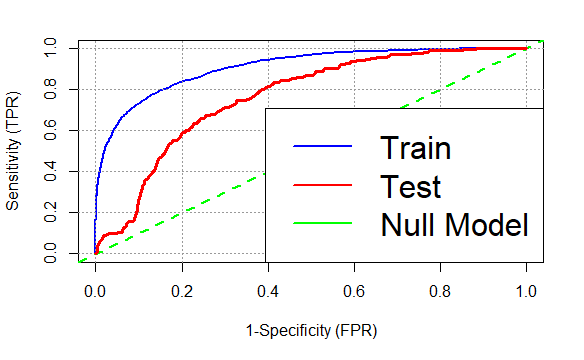

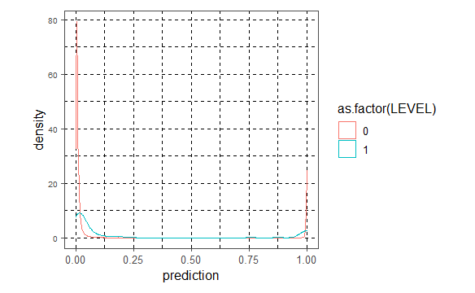

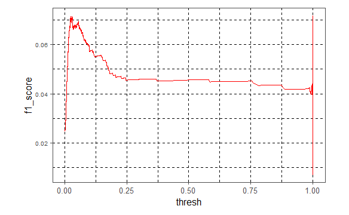

```r
model_evaluation(training_data,calibration_data, model =log_model_sel, pred_test = predict(log_model, newdata = calibration_data, type = "response"),  pred_train = predict(log_model, newdata = training_data, type = "response"),threshold =
0.01624206)
```

#### Xgboost

```r
leve_fit_fun = function(variable_matrix, labelvec) {
  cv <- xgb.cv(variable_matrix, label = labelvec,
               params=list(
                 objective="binary:logistic"
               ),
               nfold=5,
               nrounds=1000,
               print_every_n=10,
               metrics="logloss")

  evalframe <- as.data.frame(cv$evaluation_log)
  NROUNDS <- which.min(evalframe$test_logloss_mean)

  model <- xgboost(data=variable_matrix, label=labelvec,
                   params=list(
                     objective="binary:logistic"
                   ),
                   nrounds=NROUNDS,
                   verbose=FALSE)

  model
}
```

```r
temp_pred = data.frame( pred = predict(xgboost, newdata = as.matrix(training_data[pred_var])))
temp_count = temp_pred %>% group_by(pred) %>% count()
temp_count[temp_count$pred == max(temp_count$pred[temp_count$pred  < 0.01625] ) ,]
```

| pred | n |
| --- | --- |
| 0.01624934 | 1 |

```
model        precision    recall        f1   dev.norm
---------- ----------- --------- --------- ----------
training        0.9343   0.10219   0.18424        Inf
test            0.4297   0.02515   0.04752        Inf
```

|  | 0 | 1 |
| --- | --- | --- |
| 0 | 16412 | 4380 |
| 1 | 150 | 113 |

```
[1] "trainAUC: 0.975; calibrationAUC: 0.635"
```

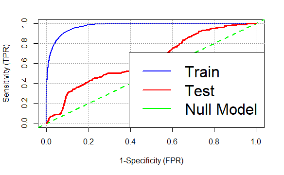

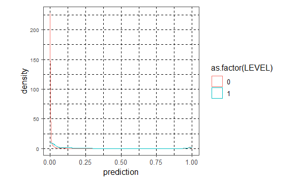

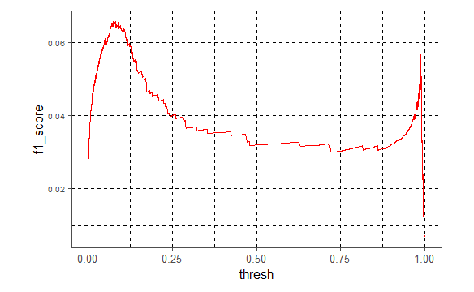

```r
model_evaluation(training_data, calibration_data, model = xgboost, pred_train = predict(xgboost, newdata = as.matrix(training_data[pred_var])), pred_test = predict(xgboost, newdata = as.matrix(calibration_data[pred_var])), threshold = 0.0162)
```

The model Performance is similar to our best model but less false positives and less true positives.

### Testing best model

```
model        precision    recall        f1   dev.norm
---------- ----------- --------- --------- ----------
training        0.7252   0.07452   0.13516        Inf
test            0.5943   0.03059   0.05818        Inf
```

|  | 0 | 1 |
| --- | --- | --- |
| 0 | 15189 | 5990 |
| 1 | 129 | 189 |

```
[1] "trainAUC: 0.893; calibrationAUC: 0.699"
```

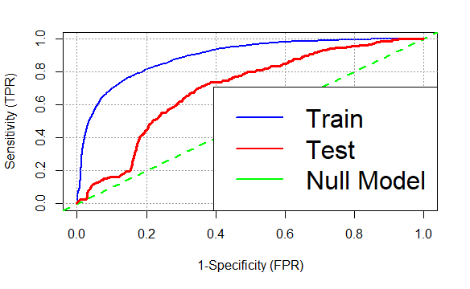

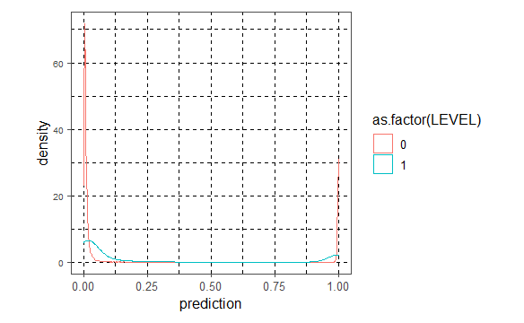

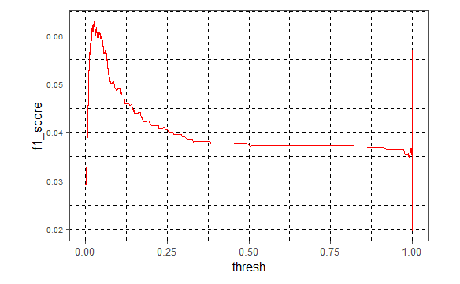

```r
model_evaluation(rbind(training_data, calibration_data),test_data, model =log_model_sel, pred_test = predict(log_model, newdata = test_data, type = "response"),  pred_train = predict(log_model, newdata = rbind(training_data, calibration_data), type = "response"),threshold =
0.01624206)
```

The performance of the model is very similar to our result from the Calibration data. This model is not useful for prediction in Critical injuries. The issue might lie with the arbitrary grouping or the simplicity of the model, I investigate if clustering method can infer relationships in the data that our current model can not.

## Clustering

I rely on Hierarchical Clustering because it is good at identifying outlier. THis is important seeing as our data is skewd to Non_critical injuries.

```r
## under sampling
level_0 = sample(size = 5000,x = 1:sum(training_data$LEVEL == 0 ), replace = T)
training_data_0 = training_data[training_data$LEVEL == 0, ]
dTrain = rbind(training_data_0[level_0,], (training_data[training_data$LEVEL == 1,])[rep(1:sum(training_data$LEVEL == 1 ),2),] )
```

```r
## under sampling of the prevelant NON-CRITICAL injuries
level_0 = sample(size = 5000,x = 1:sum(calibration_data$LEVEL == 0 ), replace = F)
calib_data_0 = calibration_data[calibration_data$LEVEL == 0, ]
dCalib = rbind(calib_data_0[level_0,], (calibration_data[calibration_data$LEVEL == 1,])[rep(1:sum(calibration_data$LEVEL == 1 ),10),] )
```

clustering

```r
h_clust = hclust(dist(dTrain[pred_var]), method = "ward.D")
cluster_sep = cutree(h_clust, 2)
table(cluster_sep)
```

```
cluster_sep
   1    2
8672  496
```

Extract and compare clusters

```r
clust1 = dTrain[names(cluster_sep)[cluster_sep == 1],]
clust2 = dTrain[names(cluster_sep)[cluster_sep == 2],]

sprintf("Non_critical injuries in the first cluster ==  %d, critical injuries in the second cluster ==  %d", sum(clust1$LEVEL == 0), sum(clust1$LEVEL == 1))
```

```
[1] "Non_critical injuries in the first cluster ==  5000, critical injuries in the second cluster ==  3672"
```

```r
sprintf("Non_critical injuries in the second cluster ==  %d, critical injuries in the second cluster ==  %d", sum(clust2$LEVEL == 0), sum(clust2$LEVEL == 1))
```

```
[1] "Non_critical injuries in the second cluster ==  0, critical injuries in the second cluster ==  496"
```

Exploring Degree of injury in the second cluster

```r
table(clust2$DEGREE_INJURY)
```

```
                      FATALITY PERM TOT OR PERM PRTL DISABLTY
                           242                            254
```

The cluster contains a good mixture of the two types of CRITICAL injury. Before Performing further assessment on the cluster. I investigate if there is a better choice for cluster number.

Set up for calculating CH critereon.

```r
# code Adopted from week 11 lecture, Computational Data analysis,
## Function to return the squared Euclidean distance of two given points x and y
sqr_euDist <- function(x, y) {
  sum((x - y)^2)
}
# Function to calculate WSS of a cluster, represented as a n-by-d matrix
# (where n and d are the numbers of rows and columns of the matrix)
# which contains only points of the cluster.
wss <- function(clustermat) {
  c0 <- colMeans(clustermat)
  sum(apply( clustermat, 1, FUN=function(row) {sqr_euDist(row, c0)} ))
}
# Function to calculate the total WSS. Argument `scaled_df`: data frame
# with normalised numerical columns. Argument `labels`: vector containing
# the cluster ID (starting at 1) for each row of the data frame.
wss_total <- function(scaled_df, labels) {
  wss.sum <- 0
  k <- length(unique(labels))
  for (i in 1:k)
  wss.sum <- wss.sum + wss(subset(scaled_df, labels == i))
  wss.sum
}
# Function to calculate total sum of squared (TSS) distance of data
# points about the (global) mean. This is the same as WSS when the
# number of clusters (k) is 1.
tss <- function(scaled_df) {
  wss(scaled_df)
}
# Function to return the CH indices computed using hierarchical
# clustering (function `hclust`) or k-means clustering (`kmeans`)
# for a vector of k values ranging from 1 to kmax.
CH_index <- function(scaled_df, kmax, method="hclust", h_clust_m = "complete") {
  if (!(method %in% c("kmeans", "hclust")))
    stop("method must be one of c('kmeans', 'hclust')")
  npts <- nrow(scaled_df)
  wss.value <- numeric(kmax) # create a vector of numeric type
  # wss.value[1] stores the WSS value for k=1 (when all the
  # data points form 1 large cluster).
  wss.value[1] <- wss(scaled_df)
  if (method == "kmeans") {
  # kmeans
    for (k in 2:kmax) {
      clustering <- kmeans(scaled_df, k, nstart=10, iter.max=100)
      wss.value[k] <- clustering$tot.withinss
    }
  } else {
  # hclust
    d <- dist(scaled_df, method="euclidean")
    pfit <- hclust(d, method=h_clust_m)
    for (k in 2:kmax) {
      labels <- cutree(pfit, k=k)
      wss.value[k] <- wss_total(scaled_df, labels)
    }
  }
  bss.value <- tss(scaled_df) - wss.value # this is a vector
  B <- bss.value / (0:(kmax-1)) # also a vector
  W <- wss.value / (npts - 1:kmax) # also a vector
  data.frame(k = 1:kmax, CH_index = B/W, WSS = wss.value)
}
```

CH criteon

```r
criterion_hcl <- CH_index(dTrain[pred_var], 15, method="hclust", h_clust_m = "ward.D")
```

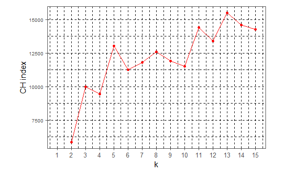

```r
ggplot() +
geom_point(data = criterion_hcl, aes(x=k, y=CH_index), colour="red") + geom_line(colour="red", data = criterion_hcl, aes(x=k, y=CH_index))  +
scale_x_continuous(breaks=1:15, labels=1:15) +
labs(y="CH index") + theme(text=element_text(size=20))+
ass2_theme
```

CH-criterion suggests a cluster 13 for Hierarchical clustering. I will investigate other cluster numbers and compare stability.

### Exploring stability of clusters using Jacard coefficient.

```r
boost2 = list()
for(i in 13:15){
  cboot.hclust2 <- clusterboot(dTrain[pred_var], clustermethod=hclustCBI,
method="ward.D", k = i)
  boost2[[i -12]] = 1 - cboot.hclust2$bootbrd/100


}
```

```r
comparison2 = data.frame(  "Number of Clusters " =  13 , "unstable %" = sum(boost2[[1]] < 0.6)/ length(boost2[[1]]),"low Cert Clusters %" = sum(boost2[[1]] >= 0.6 & boost2[[1]] < 0.75)/ length(boost2[[1]]), "mid Cert Clusters %" = sum(boost2[[1]] >= 0.75 & boost2[[1]] < 0.85)/ length(boost2[[1]]),  "high Cert Clusters %" = sum(boost2[[1]] >= 0.85)/ length(boost2[[1]]))
for(i in 2:3){
  comparison2 = rbind(comparison2, data.frame(  "Number of Clusters " =  i +12 , "unstable %" = sum(boost2[[i ]] < 0.6)/ length(boost2[[i]]),"low Cert Clusters %" = sum(boost2[[i]] >= 0.6 & boost2[[i]] < 0.75)/ length(boost2[[i]]), "mid Cert Clusters %" = sum(boost2[[i]] >= 0.75 & boost2[[i]] < 0.85)/ length(boost2[[i]]),  "high Cert Clusters %" = sum(boost2[[i]] >= 0.85)/ length(boost2[[i]])))
}


sprintf("Jacard coiffiecient for %d clusters is:", 13)
```

```
[1] "Jacard coiffiecient for 13 clusters is:"
```

```r
print(boost2[[1]])
```

```
 [1] 1.00 0.94 0.99 1.00 1.00 1.00 0.96 0.77 1.00 0.55 1.00 0.97 1.00
```

```r
sprintf("Jacard coiffiecient for %d clusters is:", 2)
```

[output not shown]

```r
print(boost2[[2]])
```

```
 [1] 1.00 1.00 1.00 0.99 1.00 1.00 1.00 0.85 1.00 0.63 0.17 1.00 0.98
[14] 1.00
```

Hierarchical clustering with 14 clusters has the highest proportion of high certainty clusters but the total number of unstable clustering and low_certainty clusters is higher than for Hierarchical with 13 clusters. I expect to witness increased stability with higher cluster number. This would suggests cluster number of 13 is more suitable. ### Explore make up of clusters in terms of Injury Level.

```r
num_cluster = 13
cluster_sep = cutree(h_clust,num_cluster   )
tot = 0
for(i in 1:num_cluster){

  print(sprintf("Non_critical injuries in the cluster %d ==  %d, critical   injuries in the second cluster ==  %d",i,  sum(dTrain[names(cluster_sep)[cluster_sep == i],"LEVEL"] == 0),  sum(dTrain[names(cluster_sep)[cluster_sep == i],"LEVEL"] == 1)))
tot = tot + sum(dTrain[names(cluster_sep)[cluster_sep == i],"LEVEL"] == 1)
}
```

```
[1] "Non_critical injuries in the cluster 1 ==  2920, critical   injuries in the second cluster ==  262"
[1] "Non_critical injuries in the cluster 2 ==  1478, critical   injuries in the second cluster ==  868"
[1] "Non_critical injuries in the cluster 3 ==  467, critical   injuries in the second cluster ==  1152"
[1] "Non_critical injuries in the cluster 4 ==  22, critical   injuries in the second cluster ==  180"
[1] "Non_critical injuries in the cluster 5 ==  83, critical   injuries in the second cluster ==  426"
[1] "Non_critical injuries in the cluster 6 ==  22, critical   injuries in the second cluster ==  370"
[1] "Non_critical injuries in the cluster 7 ==  3, critical   injuries in the second cluster ==  108"
[1] "Non_critical injuries in the cluster 8 ==  4, critical   injuries in the second cluster ==  152"
[1] "Non_critical injuries in the cluster 9 ==  1, critical   injuries in the second cluster ==  154"
[1] "Non_critical injuries in the cluster 10 ==  0, critical   injuries in the second cluster ==  250"
[1] "Non_critical injuries in the cluster 11 ==  0, critical   injuries in the second cluster ==  212"
[1] "Non_critical injuries in the cluster 12 ==  0, critical   injuries in the second cluster ==  14"
[1] "Non_critical injuries in the cluster 13 ==  0, critical   injuries in the second cluster ==  20"
```

### Visualising Graph for better comparison

```r
cluster_sep = cutree(h_clust,13 )
cluster_sep = sample(size = 300, x = cluster_sep[cluster_sep  >= 6 & cluster_sep <= 11])
princ <- prcomp(dTrain[pred_var]) # Calculate the principal components
nComp <- 2
project2D <- as.data.frame(predict(princ, newdata=dTrain[ names(cluster_sep),pred_var])[,1:nComp])
# combine with `groups` and df$Country to form a 4-column data frame
hclust.project2D <- cbind(project2D, cluster=as.factor(cluster_sep), level = dTrain[names(cluster_sep),"LEVEL"])
```

```r
library('grDevices')
find_convex_hull <- function(proj2Ddf, cluster_sep) {
  do.call(rbind,
    lapply(unique(cluster_sep),
      FUN = function(c) {
      f <- subset(proj2Ddf, cluster==c);
      f[chull(f),]
    }
    )
  )
}
hclust.hull <- find_convex_hull(hclust.project2D, cluster_sep)
```

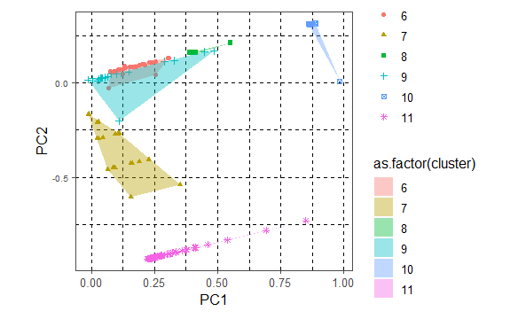

```r
ggplot(hclust.project2D, aes(x=PC1, y=PC2)) +
  geom_point(aes(shape=cluster, color=cluster)) +
  geom_polygon(data=hclust.hull, aes(group=cluster, fill=as.factor(cluster)),
  alpha=0.4, linetype=0) + theme(text=element_text(size=20)) +
  ass2_theme
```

There seems to be some good distance between cluster 8 and 11, I explore this and more below.

Exploring clusters

## Conclusion

I used data from US Accident Injury Dataset and classification models to train models and predict if an injury would be CRITICAL or NON-CRITICAL. The best classification model was the Logistic regression whose performance was slightly better than Xgboost model but both models still perform Abysmally whEn predicting CRITICAL INJURRIES but excelled at predicting NON-CRITICAL INJURIES. With the hierarchical clustering model was able to identify some patterns with a portion of the data, using Mining equipment, accident type and occupation in some cases to separate the clusters. Seeing as the clustering was able to unerth some patterns, maybe a multiclass classification model might perform better than my current method.